# Reversal Data Cleaning and Diagnostics

Sophie Paolizzi

8/3/2021

### Data Cleaning

The current cleaning code is housed in the Tidy_functions_PUBS script: refer to these functions for any questions about data cleaning. For any questions related to the definition of task variables, refer to: https://docs.google.com/spreadsheets/d/1V2UD28C_zAfH90BnNO3si6c0-qDUDFbHoU44rfdEt4I/edit#gid=1309555968.

*Load Pilot Data…*

```r
knitr::opts_chunk$set(message = FALSE, warning = FALSE)
options(knitr.duplicate.label = "allow")
##Load Packages and source scripts
pacman::p_load(tidyverse, readr, janitor, ggplot2,wesanderson, cowplot, flextable, plotly, emmeans, data.table)
setwd("~/github_repos/PUBS_Data_Verification/")
source("Tidy_functions_PUBS.R")
#reversal_data_8.16 <- data.table::fread("~/github_repos/ReversalTask/Reversal_pilot_mTurk.csv", fill = TRUE)
#load data
#load("Reversal_Task_Cleaned.Rdata")
reversal_data <- data.table::fread("~/github_repos/ReversalTask/PUBS_Pilot_Sept", fill = TRUE) %>% group_by(subject, time)

reversal_data <- reversal_data %>% mutate(subject = ifelse(time == "18:47:13", 456, subject))
subjects <- unique(reversal_data$subject)

summary <- "by_phase" #by_block, by_phase, by_block_phase
```

*Clean and transform Data. Perform basic checks….*

```r
trim_cols <- TRUE
reversal <- tidy_reversal(reversal_data)
check_tidy(reversal)
```

```
## # A tibble: 8 x 2
##   subject count
##     <dbl> <int>
## 1  104587     1
## 2  131111     1
## 3  163496     1
## 4  250866     1
## 5  324215     1
## 6  378965     1
## 7  498431     1
## 8  858936     1
```

```r
# bad <- c()
# for(i in 1:nrow(check_tidy)){
#   if(count > 1){
#     bad[nrow(check_tidy)] <- i
#   }
# }
```

*Generating results summary…*

### Pilot Results

| subject | task_phase | avg_latency | reached_criterion | NumberofTrials | NumberCorrect | percent_correct | above_threshold |
| --- | --- | --- | --- | --- | --- | --- | --- |
| 104587 | Acquisiton | 543.2925 | 8.0000 | 106.000 | 72.00 | 0.6792453 | Above |
| 104587 | Reversal | 493.9468 | 9.0000 | 94.000 | 64.00 | 0.6808511 | Above |
| 131111 | Acquisiton | 474.1000 | 8.0000 | 100.000 | 79.00 | 0.7900000 | Above |
| 131111 | Reversal | 433.8100 | 10.0000 | 100.000 | 84.00 | 0.8400000 | Above |
| 163496 | Acquisiton | 692.0870 | 9.0000 | 92.000 | 70.00 | 0.7608696 | Above |
| 163496 | Reversal | 692.1481 | 15.0000 | 108.000 | 44.00 | 0.4074074 | Below |
| 250866 | Acquisiton | 364.4301 | 14.0000 | 93.000 | 48.00 | 0.5161290 | Above |
| 250866 | Reversal | 184.5327 | 11.0000 | 107.000 | 56.00 | 0.5233645 | Above |
| 324215 | Acquisiton | 521.6552 | 8.0000 | 116.000 | 88.00 | 0.7586207 | Above |
| 324215 | Reversal | 504.0000 | 11.0000 | 85.000 | 43.00 | 0.5058824 | Above |
| 378965 | Acquisiton | 380.0762 | 10.0000 | 105.000 | 80.00 | 0.7619048 | Above |
| 378965 | Reversal | 392.4583 | 10.0000 | 96.000 | 67.00 | 0.6979167 | Above |
| 498431 | Acquisiton | 458.7881 | 9.0000 | 118.000 | 70.00 | 0.5932203 | Above |
| 498431 | Reversal | 432.9024 | 9.0000 | 82.000 | 46.00 | 0.5609756 | Above |
| 858936 | Acquisiton | 628.5138 | 8.0000 | 109.000 | 86.00 | 0.7889908 | Above |
| 858936 | Reversal | 618.6044 | 10.0000 | 91.000 | 55.00 | 0.6043956 | Above |
| Means |  | 488.4591 | 9.9375 | 100.125 | 65.75 | 0.6543609 |  |

```r
##N.B. For actual analysis, hang here and create drop_irregular function that prints summaries and has options to get rid of:
## bad subjects (those with < avg accuracy overall)
##bad blocks (blocks with <50% accuracy)
##bad trials (latency > 3000 - this should also encompass noresponse)
```

**Figure 1**. This chunk prints an overall view of reaction time.

```
## $`104587`
```

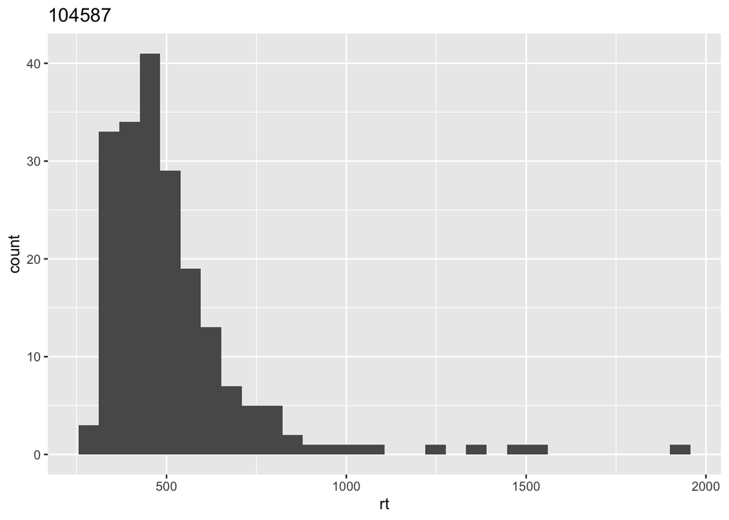

```
##
## $`131111`
```

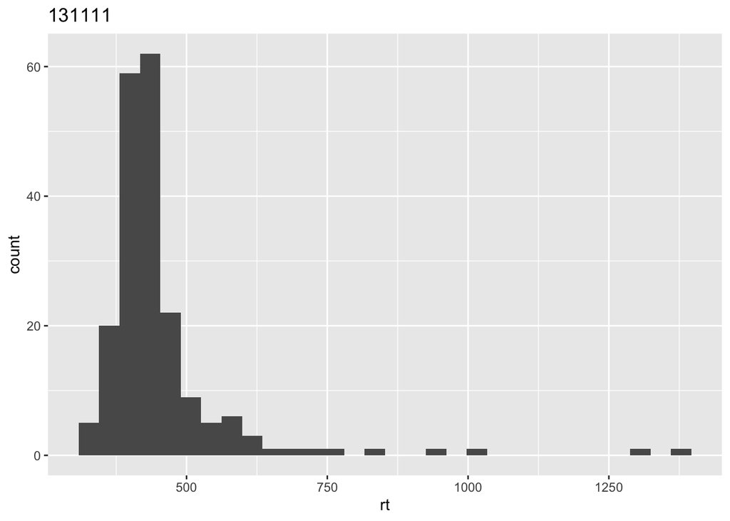

```
##
## $`163496`
```

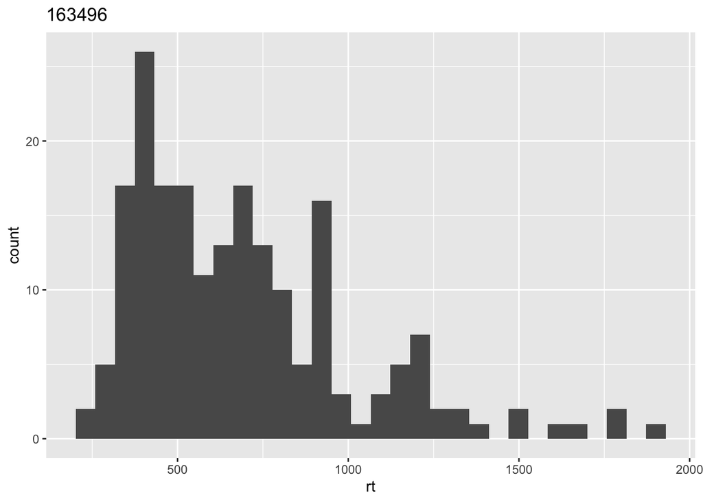

```
##
## $`250866`
```

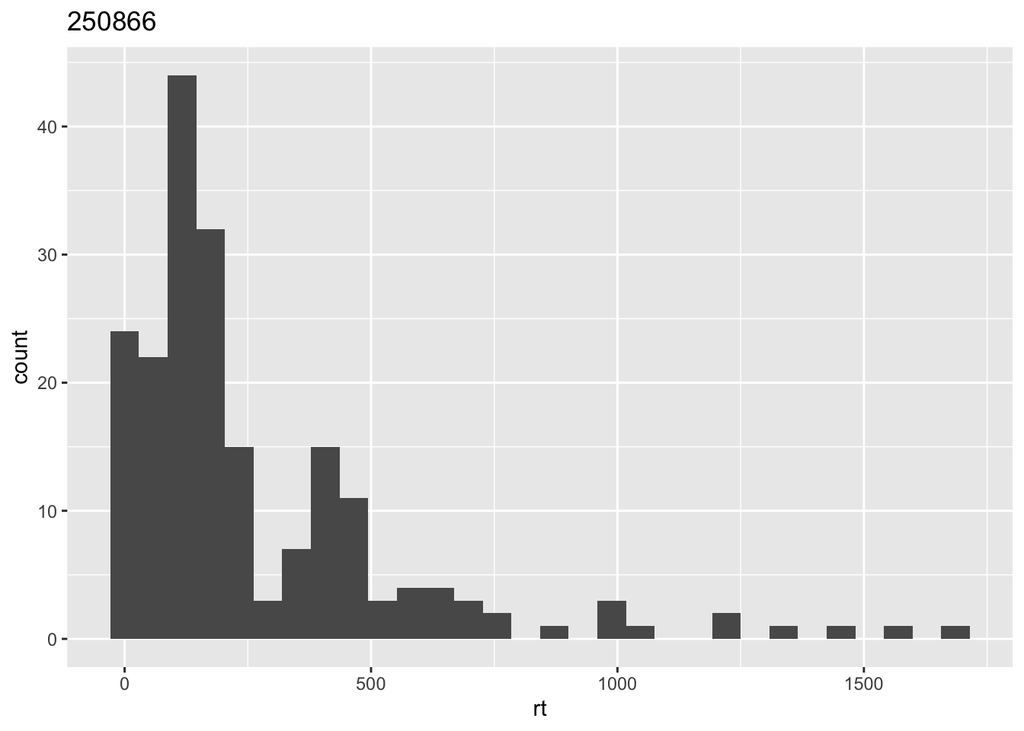

```
##
## $`324215`
```

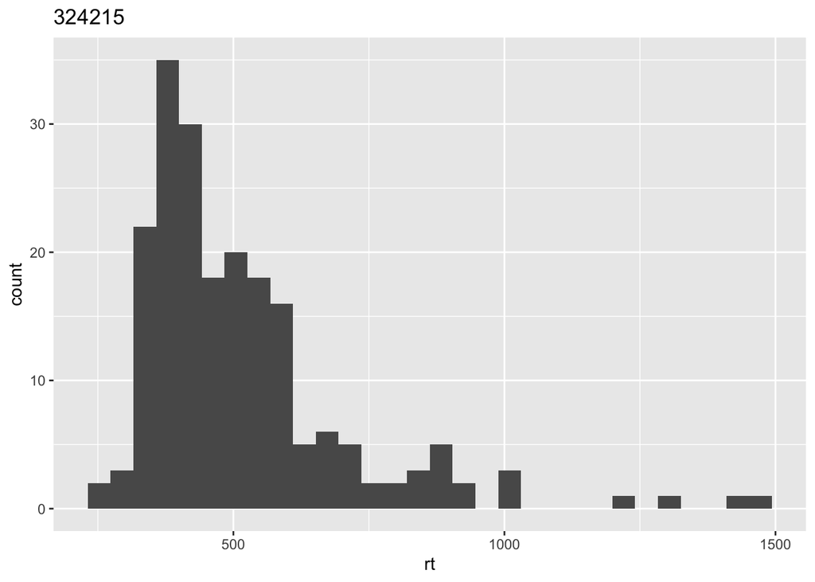

```
##
## $`378965`
```

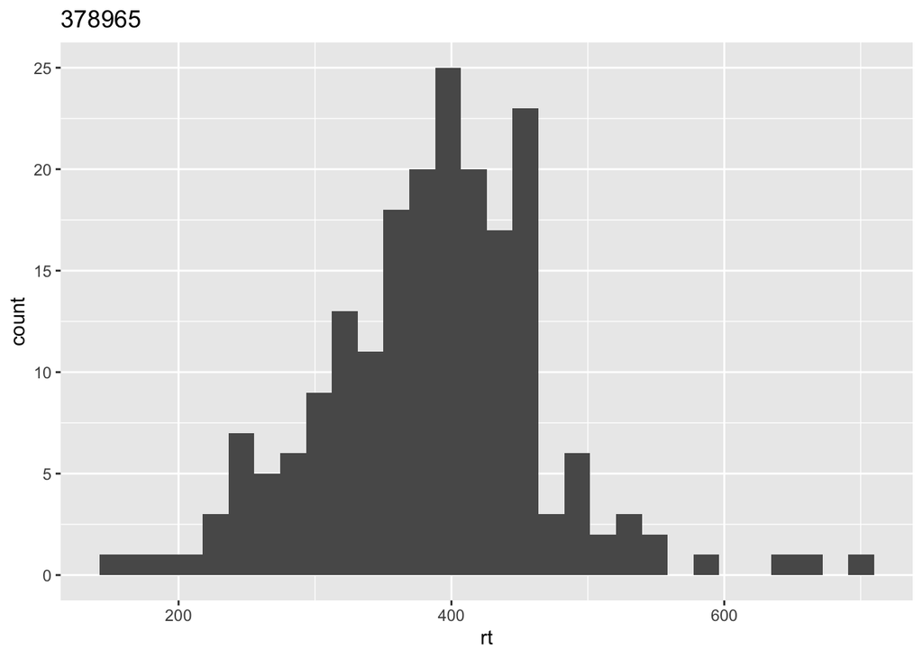

```
##
## $`498431`
```

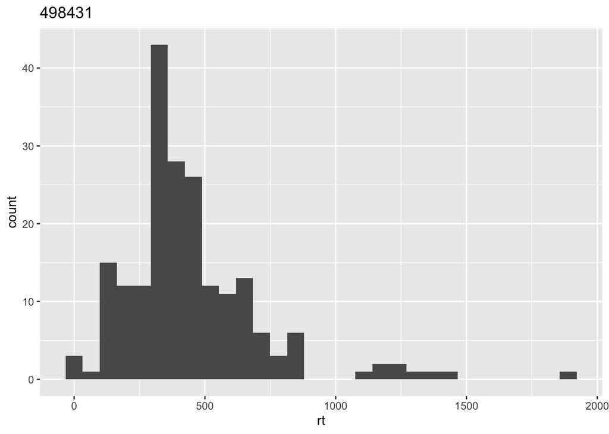

```
##
## $`858936`
```

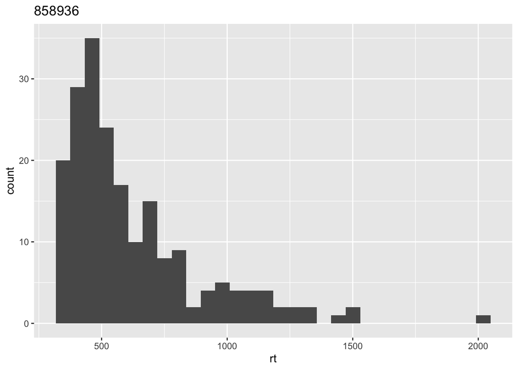

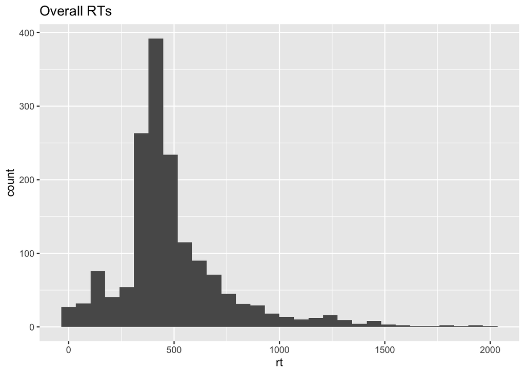

```r
rts <- list()
for (i in subjects) {
  s <- reversal %>% dplyr::filter(subject == i)
rt_hist <- ggplot(s, aes(rt), stat = "bin") + geom_histogram() + ggtitle(i)
rts[[i]] <- rt_hist
}



rts[[length(rts) + 1]] <- rt_hist <- ggplot(reversal, aes(rt), stat = "bin") + geom_histogram() + ggtitle("Overall RTs")
rts[]
```

```r
summary(reversal$rt)
```

```
##    Min. 1st Qu.  Median    Mean 3rd Qu.    Max.
##     0.0   361.2   434.0   488.3   561.8  2000.0
```

```r
for (i in subjects) {
  d <- reversal %>% dplyr::filter(subject == i)
  scatter <- ggplot(d, aes(x=trial_number, y = rightleftcorrect, color = as.factor(ResponseCorrect))) +
     geom_point() +
     geom_vline(aes(xintercept = reversal_trial, color = "Reversal Point")) +
     scale_color_manual(labels = c("Incorrect", "Correct", "Reversal Point"),
                        values = (wes_palette("Cavalcanti1")[c(5,4,2)])) +
     xlab("Trial Number") + ylab("Response Type") + ggtitle(i) +
     facet_wrap(~block_number)
  scatter[[i]] <- scatter

  if (summary == "by_block_phase"){
    h <- obj %>% filter(subject == i) %>% group_by(task_phase)
    hist <- ggplot(h, aes(y=percent_correct, x = task_phase, fill = above_threshold)) +
      geom_bar(stat = "identity") + scale_fill_manual(values = (wes_palette("Cavalcanti1")[c(4,5)])) + ylab("Percentage Correct") + xlab("") +  facet_grid(~ block_number)
 hist[[i]] <- hist
  } else if (summary == "by_block"){
    h <- obj %>% filter(subject == i) %>% group_by(block_number)
    hist <- ggplot(h, aes(y=percent_correct, x = block_number, fill = above_threshold)) +
      geom_bar(stat = "identity") + scale_fill_manual(values = (wes_palette("Cavalcanti1")[c(4,5)])) + ylab("Percentage Correct") + xlab("")
  } else if (summary == "by_phase"){
    h <- obj %>% filter(subject == i) %>% group_by(task_phase)
    hist <- ggplot(h, aes(y=percent_correct, x = task_phase, fill = above_threshold)) +
      geom_bar(stat = "identity") + scale_fill_manual(values = (wes_palette("Cavalcanti1")[c(4,5)])) + ylab("Percentage Correct") + xlab("")
  }

 plot_subjects[[i]] <- list(scatter, hist)
 cowplot <- cowplot::plot_grid(scatter, hist, nrow = 2)
 cowplot_list[[i]] <- cowplot
}
```

## Summary of Reversal Findings

````r
template <- c(
    "### cowplot_list {{y}}\n",
    "```{r, echo = FALSE}\n",
    "cowplot_list[[{{y}}]] \n",
    "```\n",
    "\n"
  )

plots <- lapply(1:length(cowplot_list), function(y) {knitr::knit_expand(text = template)})
````

### cowplot_list 1

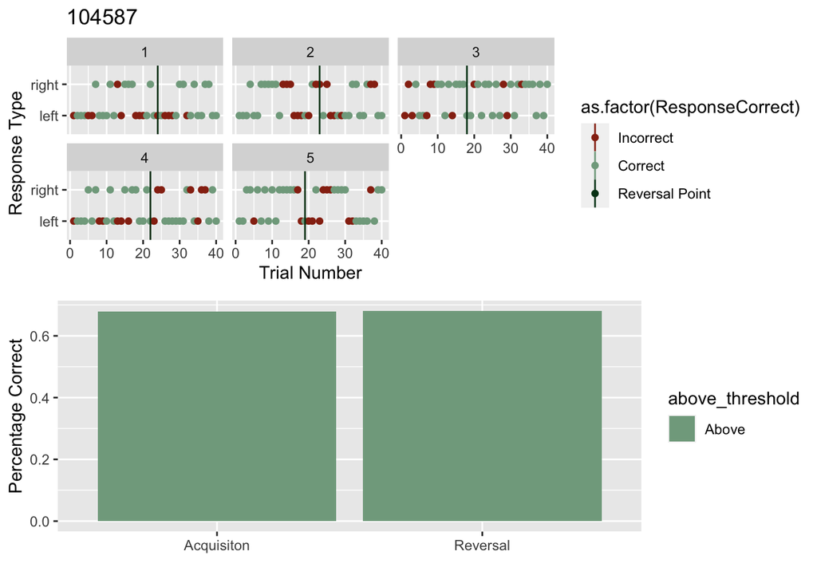

### cowplot_list 2

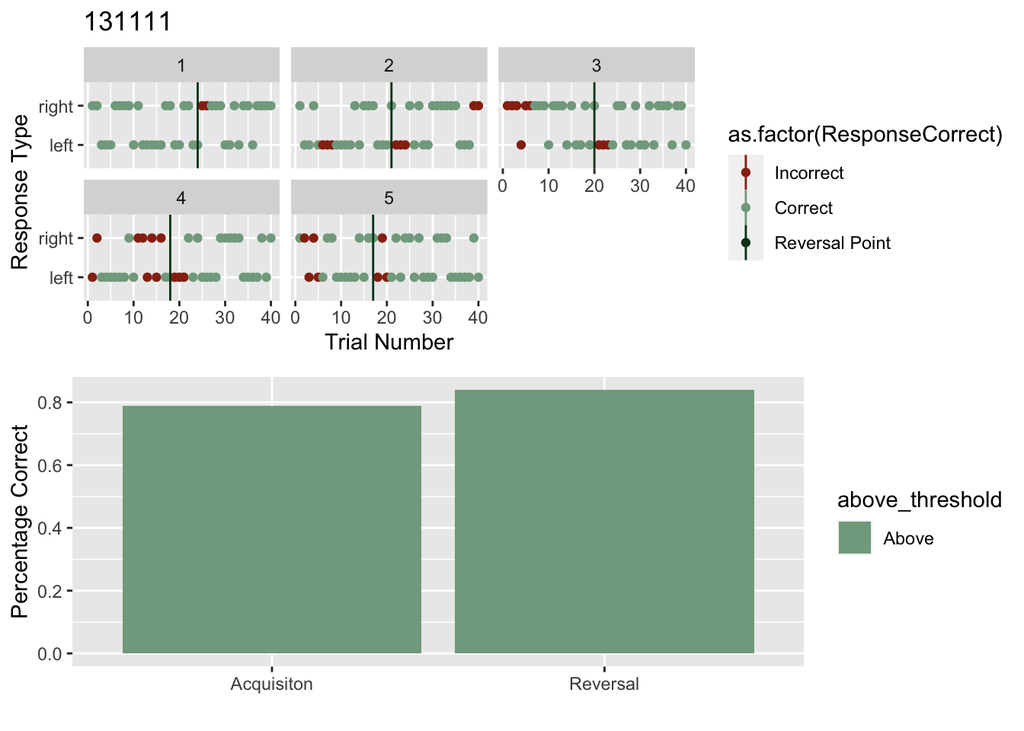

### cowplot_list 3

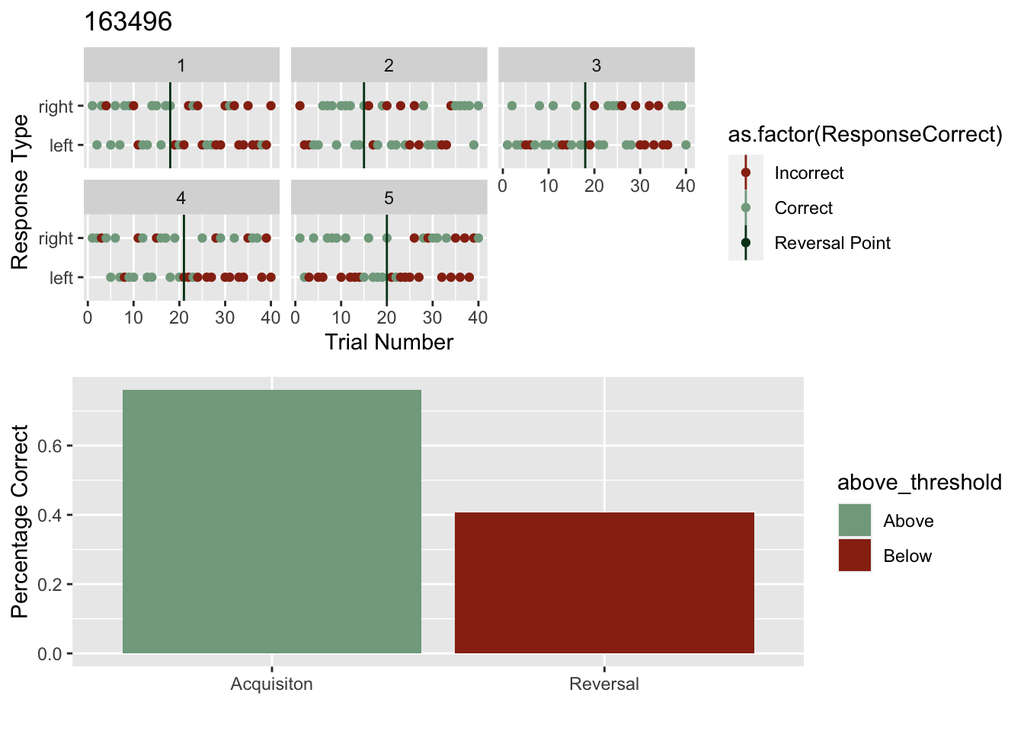

### cowplot_list 4

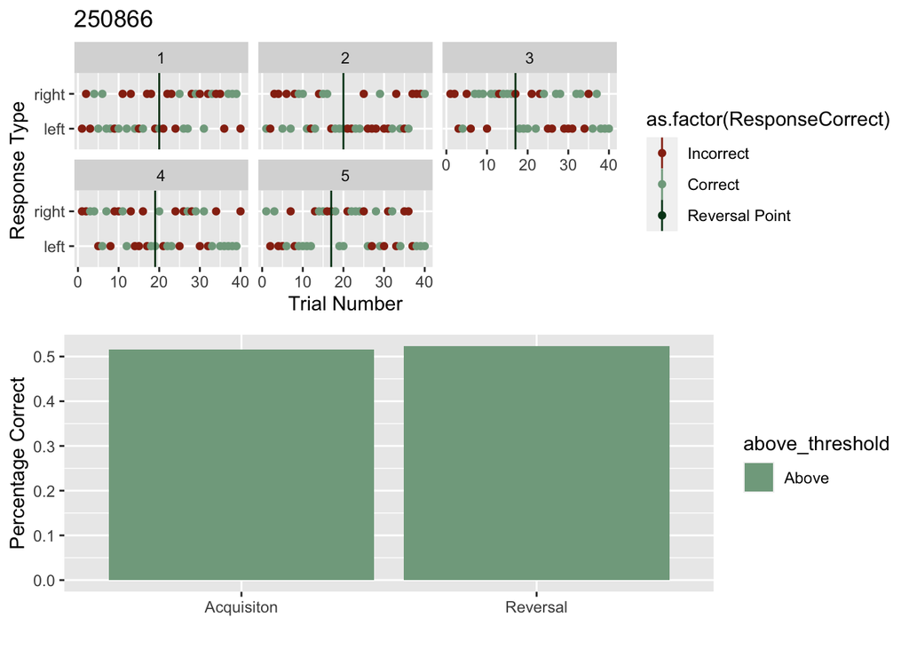

### cowplot_list 5

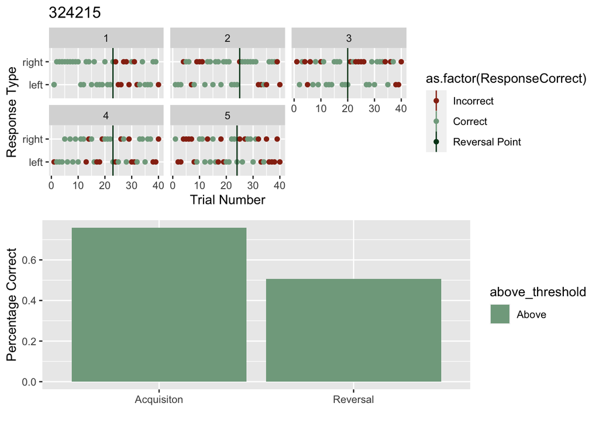

### cowplot_list 6

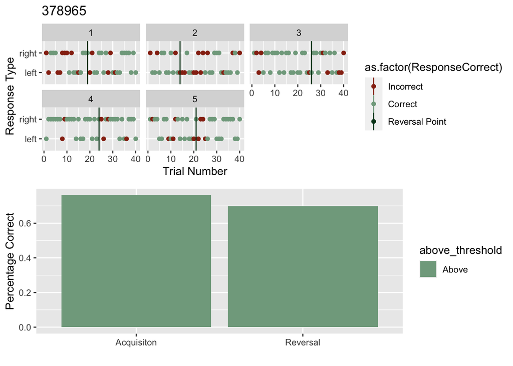

### cowplot_list 7

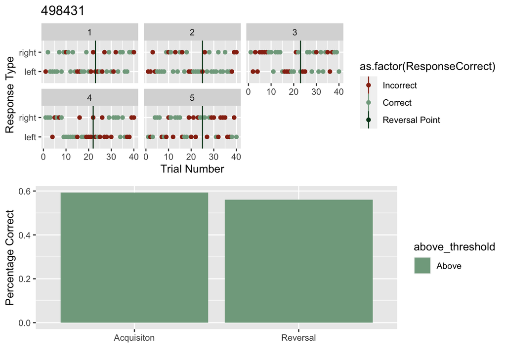

### cowplot_list 8

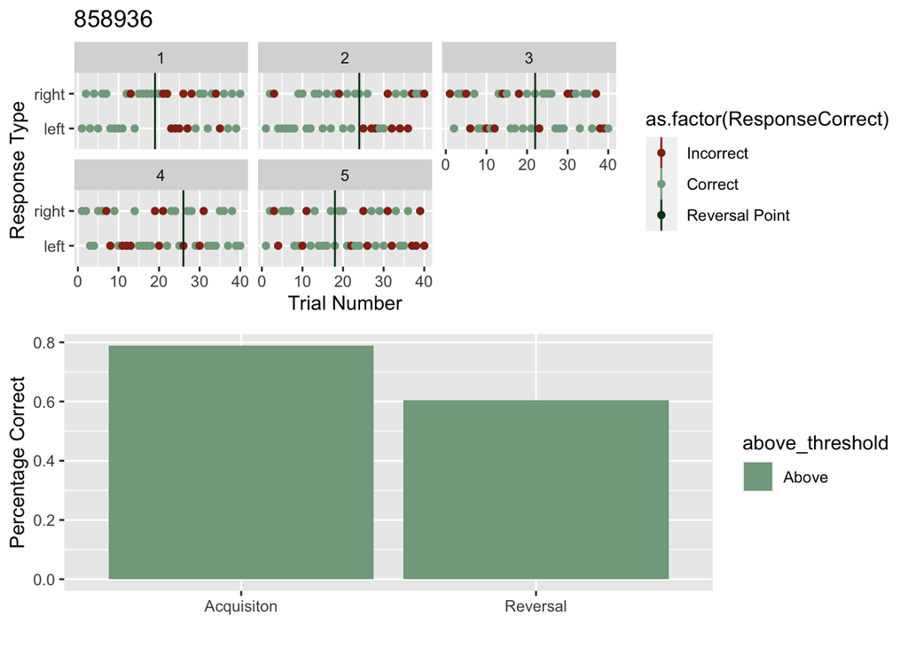

```r
a_1 <- aov(rt ~ task_phase, data = reversal)
summary(a_1)
```

```
##               Df    Sum Sq Mean Sq F value Pr(>F)
## task_phase     1    636717  636717   9.027 0.0027 **
## Residuals   1600 112853596   70533
## ---
## Signif. codes:  0 '***' 0.001 '**' 0.01 '*' 0.05 '.' 0.1 ' ' 1
```

```r
a_1 <- aov(rt ~ block_number, data = reversal)
summary(a_1)
```

```
##                Df    Sum Sq Mean Sq F value   Pr(>F)
## block_number    1   4427791 4427791   64.96 1.48e-15 ***
## Residuals    1600 109062522   68164
## ---
## Signif. codes:  0 '***' 0.001 '**' 0.01 '*' 0.05 '.' 0.1 ' ' 1
```

```r
rt_trialnum <- lm(rt ~ total_trialnum + task_phase + block_number, data = reversal)
summary(rt_trialnum)
```

```
##
## Call:
## lm(formula = rt ~ total_trialnum + task_phase + block_number,
##     data = reversal)
##
## Residuals:
##     Min      1Q  Median      3Q     Max
## -529.23 -133.80  -38.56   73.13 1566.97
##
## Coefficients:
##                    Estimate Std. Error t value Pr(>|t|)
## (Intercept)         440.974     34.075  12.941  < 2e-16 ***
## total_trialnum       -6.158      1.044  -5.899 4.46e-09 ***
## task_phaseReversal   81.691     24.157   3.382 0.000738 ***
## block_number        209.018     41.954   4.982 6.97e-07 ***
## ---
## Signif. codes:  0 '***' 0.001 '**' 0.01 '*' 0.05 '.' 0.1 ' ' 1
##
## Residual standard error: 257.7 on 1598 degrees of freedom
## Multiple R-squared:  0.06469,    Adjusted R-squared:  0.06293
## F-statistic: 36.84 on 3 and 1598 DF,  p-value: < 2.2e-16
```

```r
emmeans(rt_trialnum, "task_phase")
```

```
##  task_phase emmean   SE   df lower.CL upper.CL
##  Acquisiton    449 13.2 1598      424      475
##  Reversal      531 14.2 1598      503      559
##
## Confidence level used: 0.95
```

```r
emmeans(rt_trialnum, "block_number")
```

```
##  block_number emmean   SE   df lower.CL upper.CL
##             3    490 6.46 1598      478      503
##
## Results are averaged over the levels of: task_phase
## Confidence level used: 0.95
```

## Issues Warranting Discussion

### For Michael Discussion 9/23

##### Data Visualizations and Verification

SGP added an option at the top of the script to examine data by block, phase, or both. This will hopefully help to adjust views on data easily. it would make sense to add in a function which returns particularly bad blocks in terms of RT.

##### Issues with Task + Plans for remedying

A few critical concerns came up immediately: First, there are IDs that overlap. This was updated in the qualtrics survey, and luckily data was still distinguishable by time stamp. Second, one of those repeated subject did not complete the task fully (they bailed in the middle of the cannon task). - It’s unclear why, but this means I cannot pay this participant. They also only completed 40% of the surveys, indicating to me they were not going to receive payment anyway. Third, it seems the workerIDs were not recorded in the qualtrics survey. This has now been updated and will be testing this evening.

This next block is creating all variables I cannot record directly from inquisit for whatever reason (not recording at numeric, wrong block number, etc.). I worked to create as many variables as possible within the task structure, but there are still a few missing that I have to transform offline. 1. Confirm that final data is generating data that makes sense. 2. Generate vector of bad RTS and provide info on possible transforms. 3. Ensure that Qualtrics is not re-using IDs (lengthen randomID string). 4. add workerIds to embedded data so data can be matched across participants more easily.

### For Michael Discussion 8/26 - ARCHIVE

On average, participants made the “correct” choice approximately 80% of the time, and made at least 10 correct choices by trial 17. Both of these outcomes suggest the block length can be shortened as suggested by MNH to as little as 50 trials. Regarding data verification and visualization, it will be important to look at RT data more explicitly in the larger sample. Based on the pilot, it looks like it could be handled pretty easily with a log or invesrse transform.

**Task Recomendations - For Michael Discussion** 1. Block length to 50 trials per MNH’s suggestion. Given subjects learned the contingencies in an average of 16 trials, this seems about correct. For time’s sake, I’m thinking of erring on the side of 4 blocks of 50 trials. 2. Explicitly instruct participants to click as quickly and accurately as possible, and shorten response windows such that the entire task will take between 8 and 10 minutes. See “Task Timing” for more details. https://docs.google.com/spreadsheets/d/1V2UD28C_zAfH90BnNO3si6c0-qDUDFbHoU44rfdEt4I/edit#gid=390744519 3. Combine stimulus selection and feedback phases, to save time? 4. Collect 10-15 subjects and check for final timing.

**Data Check Plans** 1. Translate dplyr operations into usable functions and try to duplicate as little as possible across tasks.  
2. drop_irregular function 3. Check RTs and provide info on possible transforms